# TFM_final

### Clusterización jerárquica acumulativa. Prueba con distintos “linkages”

Después de esta primera descripción pasamos a la clusterización. Al no tener un número claro de clusteres predeterminado y dado el relativo número pequeño de puntos, pensamos que los dendogramas nos pueden dar una idea muy clara de las posibles agrupaciones y distancias entre ellas. Por esta razón nos decantamos por implementar clustering jerárquico acumulativo.

Dentro de estas opción de clustering probaremos con los “linkages” Ward (basado en la similitud entre puntos de un mismo cluster, idea similar al método k-means), el complete (suele formar grupos compactos) y el average (utilizado como un método a medio camino). Observaremos los dendogramas para poder tener una idea inicial de un rango de número de clusteres a probar. En la elección final influirá el que sean distinguibles los grupos más aislados comentados en la descripción deneral, y a ser posible que existacuniformidad de signos en un mismo cluster, para una interpretación más clara según los factores F1 y F3.

Veamos pues los dendogramas:

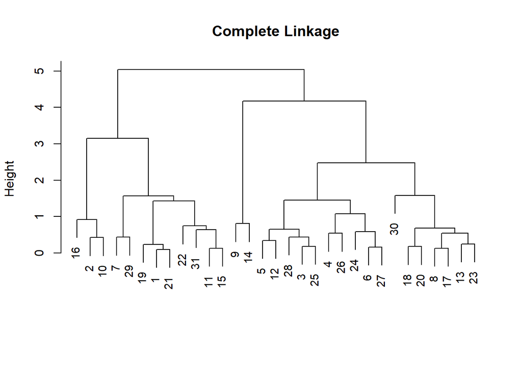

```r
# estandarización previa al clustering
ptos.F.scl <- scale(dfHD.factoresPCA.expl[,c(3,4)])

# jerarquico con los 3 linkages
hc.complete = hclust(dist(ptos.F.scl), method ="complete")
hc.average = hclust(dist(ptos.F.scl), method ="average")
hc.ward = hclust(dist(ptos.F.scl), method ="ward.D")

# gráficas dendogramas
plot(hc.complete ,main =" Complete Linkage ",xlab="", sub ="",cex =.9)
```

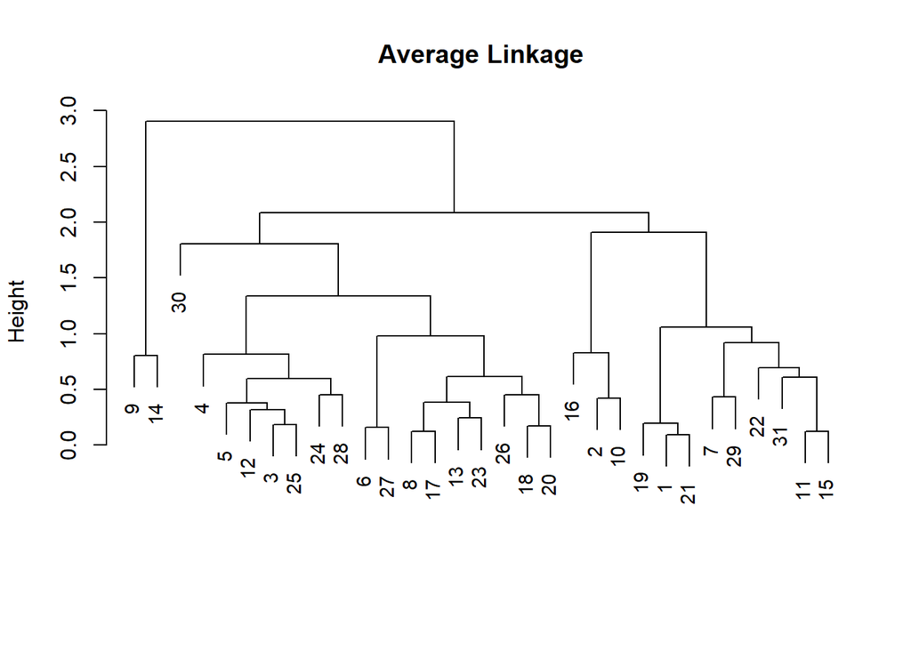

```r
plot(hc.average , main =" Average Linkage ",xlab="", sub ="",cex =.9)
```

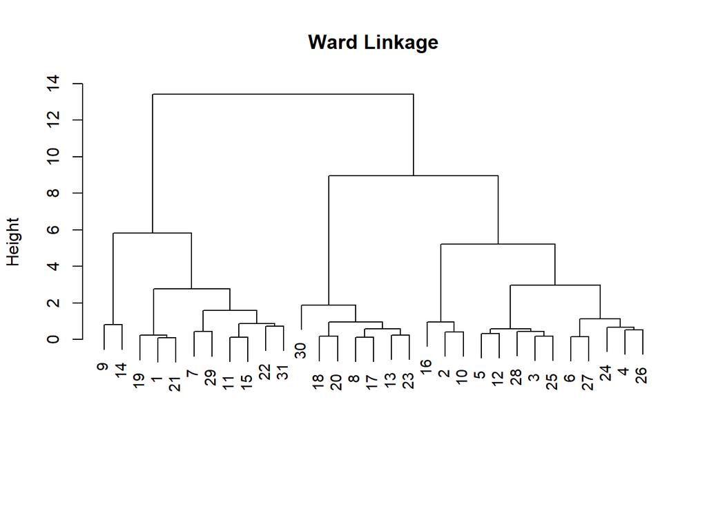

```r
plot(hc.ward , main =" Ward Linkage ",xlab="", sub ="",cex =.9 )
```

```r
# nombre de los países de los grupos más aislados

idx_paises <- c(2,10,16,9,14,30)

for (pais in idx_paises) {

  print(dfHD.factoresPCA.expl[pais,"GEO"])

}
```

```
## [1] Belgium
## 31 Levels: Austria Belgium Bulgaria Croatia Cyprus Czechia ... United Kingdom
## [1] France
## 31 Levels: Austria Belgium Bulgaria Croatia Cyprus Czechia ... United Kingdom
## [1] Italy
## 31 Levels: Austria Belgium Bulgaria Croatia Cyprus Czechia ... United Kingdom
## [1] Finland
## 31 Levels: Austria Belgium Bulgaria Croatia Cyprus Czechia ... United Kingdom
## [1] Iceland
## 31 Levels: Austria Belgium Bulgaria Croatia Cyprus Czechia ... United Kingdom
## [1] Turkey
## 31 Levels: Austria Belgium Bulgaria Croatia Cyprus Czechia ... United Kingdom
```

Como vemos los 3 primeros (Bélgica, Francia, Italia, zona superior derecha), luegos los dos siguientes (Finlandia e Islandia, esquina inferior izquierda) y el último(Turquía aislado en la esquina inferio derecha) los grupos más aislados que distinguimos en la gráfica inicial.

En el caso del “average” parece un buen punto de partida 6 clusteres. Se siguen distinguiendo los grupos comentados más separados.

Por último para el “Ward” se necesitaría un valor más alto de partida, entre 6 y 7, de hecho más alto todavia para distinguir los 3 grupos aislados.

Decidimos para los 3 tomar en un primer momento el número máximo a probar de 8 clusteres, excepto para el ward comentado que llegamos en principio hasta 9. Dibujaremos la gráfica para todos los valores de clusteres (corte indicado a la función ‘cutree’).

Veamos los resultados para “complete”:

```r
# librería para evitar en lo posible solapamiento etiquetas
library(ggrepel)
```

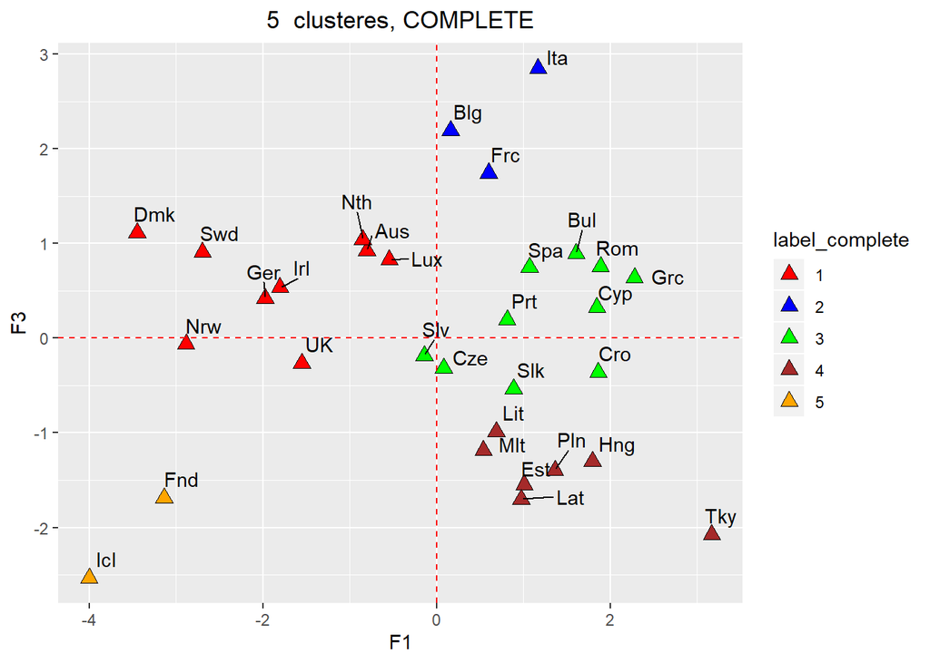

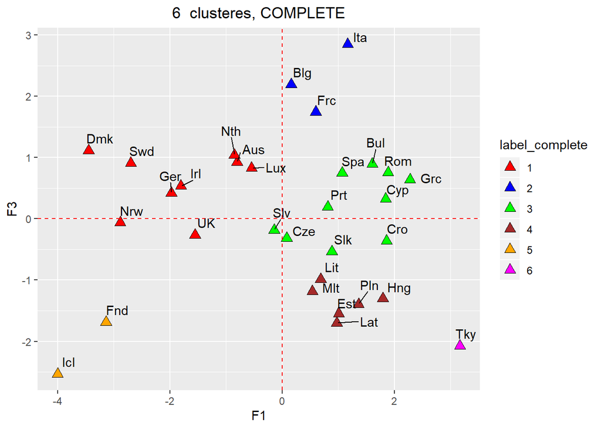

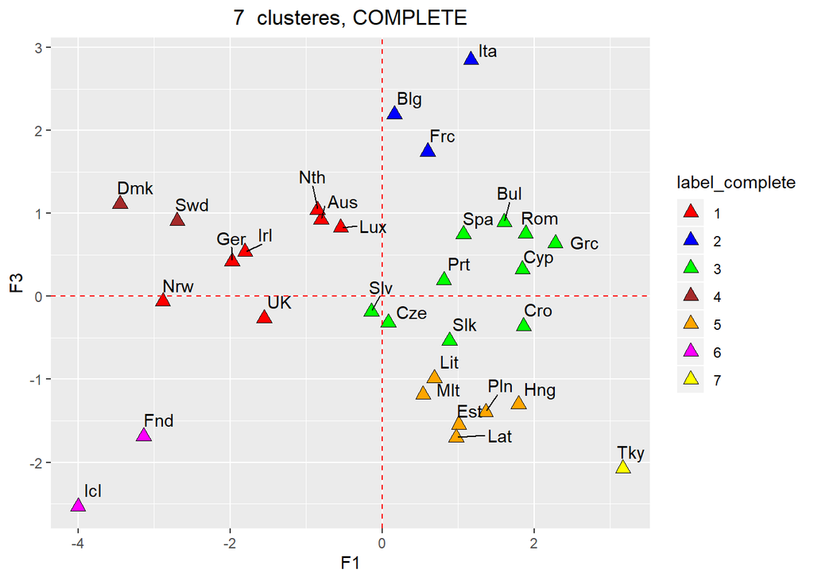

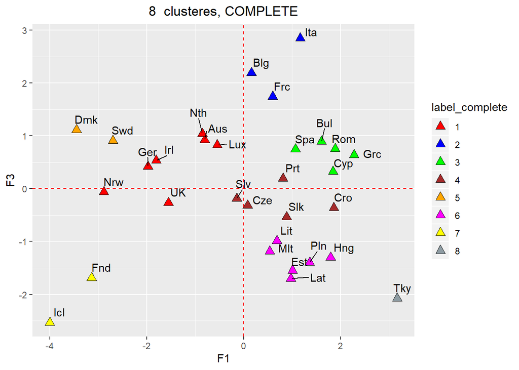

```r
# paleta de color personalizada, para una mejor distinción clústeres
paleta.pers <- c("red", "blue", "green", "brown", "orange",
"magenta", "yellow", "#8E9CA3", "#556670", "#000000")

# gráficas para cada número de clústeres elegido
for(n_clust in seq(5,8,by = 1)){

  # corte dendograma para nº de clusteres elegido
  dfHD.factoresPCA.expl$label_complete <- as.factor(cutree(hc.complete,n_clust))


  #grafica clustering
  plot(ggplot(data = dfHD.factoresPCA.expl, mapping = aes(x = F1, y = F3)) +
geom_point(mapping = aes(x = F1, y = F3, fill = label_complete), shape=24,size=3) +
  geom_hline(yintercept = 0, color="red", linetype="dashed") +
  geom_vline(xintercept = 0, color="red", linetype="dashed") +
  geom_text_repel(label=dfHD.factoresPCA.expl$abrev, nudge_x = 0.2, nudge_y = 0.2) +
  labs(title = paste(n_clust," clusteres, COMPLETE")) +
ylab("F3") +
xlab("F1") +
  theme(plot.title = element_text(hjust = 0.5)) +
  scale_fill_manual(values = paleta.pers)
       )

}
```

Los correspondientes a “average”:

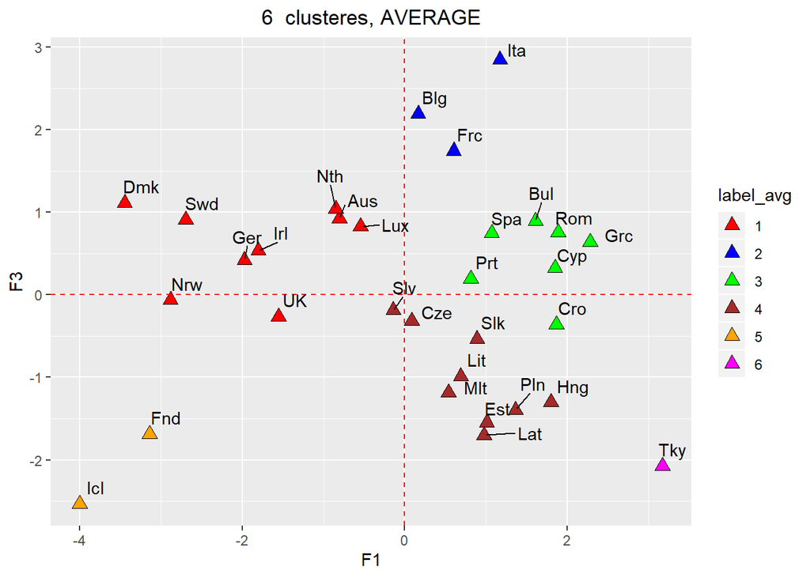

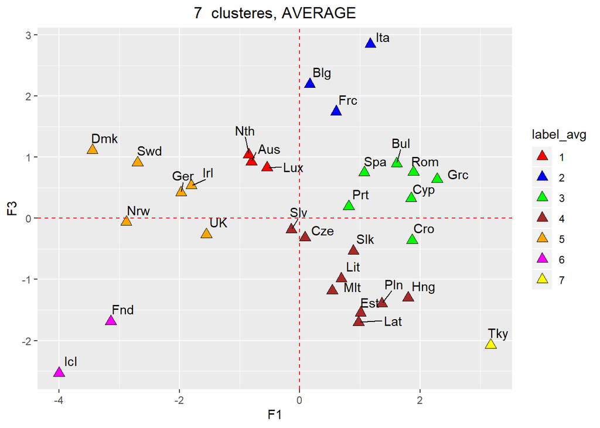

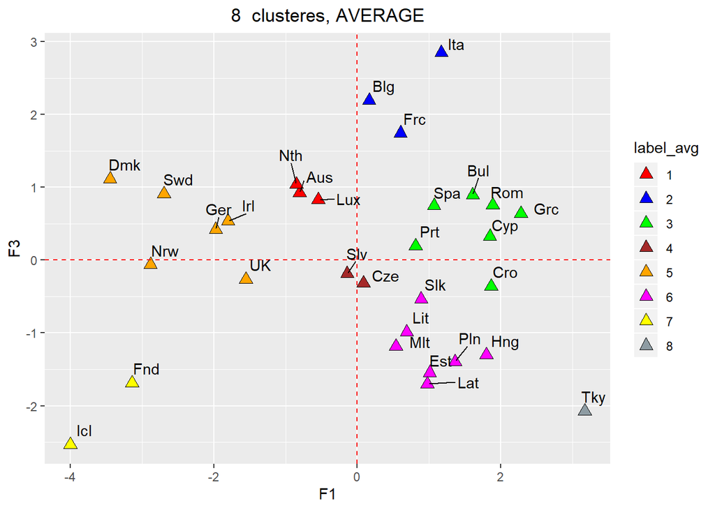

```r
for(n_clust in seq(6,8,by = 1)){

  # corte dendograma para nº de clusteres elegido
  dfHD.factoresPCA.expl$label_avg <- as.factor(cutree(hc.average,n_clust))

  # grafica clustering
  plot(ggplot(data = dfHD.factoresPCA.expl, mapping = aes(x = F1, y = F3)) +
geom_point(mapping = aes(x = F1, y = F3, fill = label_avg), shape=24,size=3) +
  geom_hline(yintercept = 0, color="red", linetype="dashed") +
  geom_vline(xintercept = 0, color="red", linetype="dashed") +
  geom_text_repel(label=dfHD.factoresPCA.expl$abrev, nudge_x = 0.2, nudge_y = 0.2) +
  labs(title = paste(n_clust," clusteres, AVERAGE")) +
ylab("F3") +
xlab("F1") +
  theme(plot.title = element_text(hjust = 0.5)) +
  scale_fill_manual(values = paleta.pers)
       )

}
```

Y por último los de “ward”:

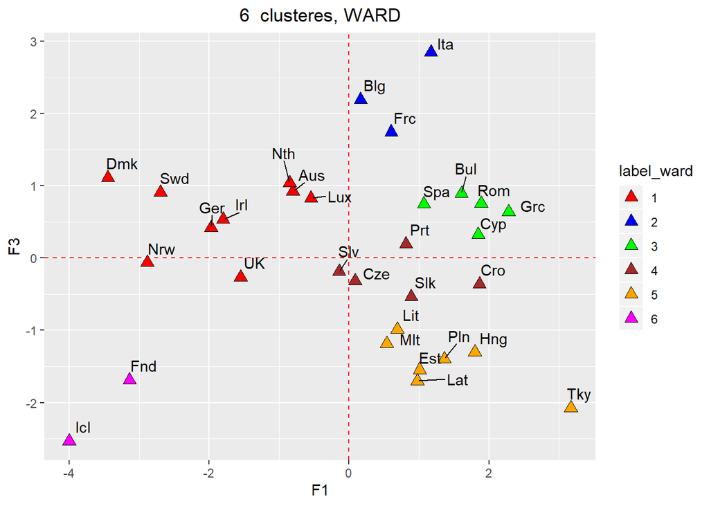

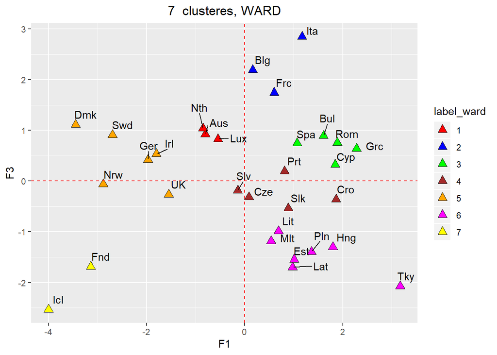

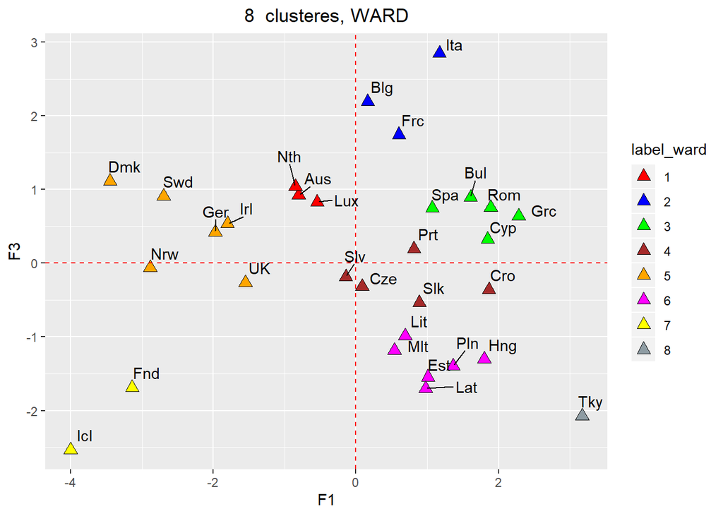

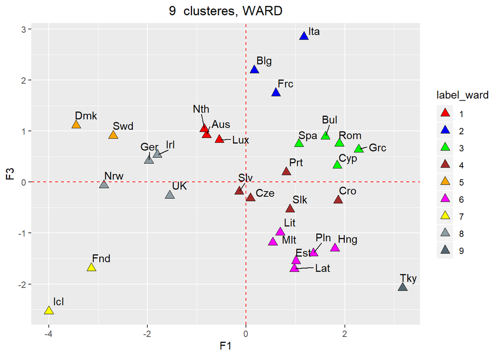

```r
for(n_clust in seq(6,9,by = 1)){

  # corte dendograma para nº de clusteres elegido
  dfHD.factoresPCA.expl$label_ward <- as.factor(cutree(hc.ward,n_clust))

  # grafica clustering
  plot(ggplot(data = dfHD.factoresPCA.expl, mapping = aes(x = F1, y = F3)) +
geom_point(mapping = aes(x = F1, y = F3, fill = label_ward), shape=24,size=3) +
  geom_hline(yintercept = 0, color="red", linetype="dashed") +
  geom_vline(xintercept = 0, color="red", linetype="dashed") +
  geom_text_repel(label=dfHD.factoresPCA.expl$abrev, nudge_x = 0.2, nudge_y = 0.2) +
  labs(title = paste(n_clust," clusteres, WARD")) +
ylab("F3") +
xlab("F1") +
  theme(plot.title = element_text(hjust = 0.5)) +
  scale_fill_manual(values = paleta.pers)
       )

}
```

Vistos todas las opciones en primer lugar descartamos el linkage “ward” ya que para llegar a la distinción de los 3 grupos particulares necesita un número tan alto (8) que implica en nuestra opinión una excesiva división en la parte derecha (sin grandes diferencias en las coordenadas).

En el caso del “complete” con 6 ya distingue las particularidades. Tiene como negativo que la disposición mayoritaria a la derecha la divide en 2 grupos, el superior con disparidad destacable del signo de F3 dentro del grupo.

### Análisis de los grupos resultados de la clusterización elegida.

Pasamos a analizar para el linkage “average” el caso de 8 clusteres ya que, mediante uniones de ciertos grupos, nos permitirá también hacernos una idea del análisis correspondiente a 6 clusteres.

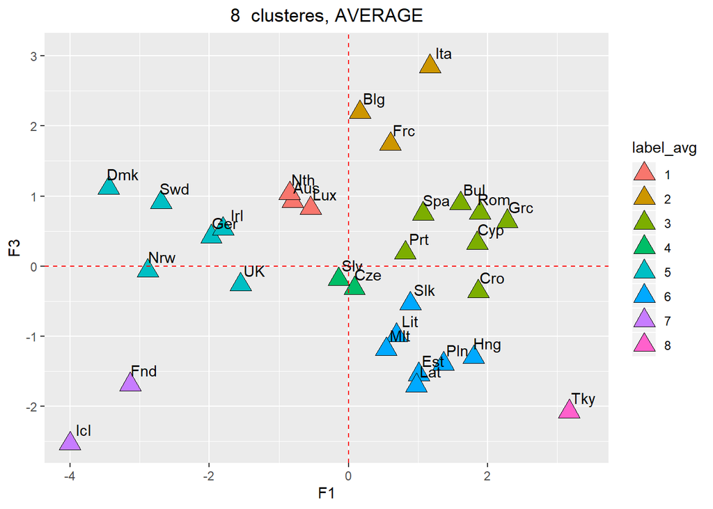

```r
# linkage "average", 8 clusteres
n_clust = 8
dfHD.factoresPCA.expl$label_avg <- as.factor(cutree(hc.average,n_clust))

# grafica clusterizacion
ggplot(data = dfHD.factoresPCA.expl, mapping = aes(x = F1, y = F3)) +
geom_point(mapping = aes(x = F1, y = F3, fill = label_avg), shape=24,size=5) +
  geom_hline(yintercept = 0, color="red", linetype="dashed") +
  geom_vline(xintercept = 0, color="red", linetype="dashed") +
  geom_text(label=dfHD.factoresPCA.expl$abrev, nudge_x = 0.2, nudge_y = 0.2, check_overlap = F) +
  labs(title = paste(n_clust," clusteres, AVERAGE")) +
ylab("F3") +
xlab("F1") +
  theme(plot.title = element_text(hjust = 0.5))
```

Recordemos antes el carácter de los factores F1 y F3, y la posible influencia del factor bivalente “non_prescrib_med_use_pct” :

- **F1:** “Soporte social insuficiente frente al Gasto sanitario y hábitos de vida considerados positivos”. La valoración positiva del estado de salud (SPHpos) se corresponde con el signo negativo.
- **F3:** “Gasto sanitario frente a mala condición física (sobrepeso, enfermedad crónica)”. La valoración positiva del estado de salud (SPHpos) se corresponde con el signo positivo.
- **factor bivalente variable “non_prescrib_med_use_pct”**, que actua a favor (signo negativo) de la valoración positiva de salud para F1 y en contra (signo negativo) para F3

Dadas las relaciones de los signos de F1 y F2 con la valoración positiva de salud, en la gráfica la mejor situación la tendrán los países que se encuentren en el cuadrante superior izquierda, y se encontararán con la peor valoración los del cuadrante inferior derecha.

#### 1.- En la situación privilegiada del cuadrante superior izquierda nos encontramos con 2 grupos:

**A) {Alemania, Dinamarca, Noruega, Suecia, Reino Unido e Irlanda}**: Mejor grupo, valores negativos medios-altos de F1 y positivos medio-bajos de F3.

Todos se encuentran entre los valores más altos de Gasto Sanitario.

Entre los hábitos considerados positivos también todos con valores altos-medios de Actividad Física, Bebedores Habituales y Fumadores Ocasionales (en este último caso a excepción de Reino Unido que es muy bajo). En cuanto al Consumo de Frutas y Verduras recomendado encontramos dos comportamientos dentro del grupo, de los valores más altos (los 3 de cabeza) para Reino Unido, Irlanda y Dinamarca, y en el grupo de los medios-bajos para Alemania, Noruega y Suecia. Este doble comportamiento vendría a explicar el que este grupo sea menos concentrado, esté algo más estirado. En global buenos valores para los hábitos considerados positivos.

Soporte Social insuficiente en valores medio en el caso de Alemania y bajos en el resto. Hablando del Sobrepeso tenemos valores bajos excepto para Irlanda y Reino Unido. En cuanto a la tasa de Enfermedad crónica valores medios-altos excepto para Irlanda y Dinamarca. Estas condiciones de sobrepeso y enfermedad crónica explicarían los valores medio-bajos de F2. Al igual las excepciones comentadas justificarían que este cluster esté menos concentrado, un poco más estirado.

El grupo mejor situado con valores en general óptimos para la valoración positiva.

**B) {Holanda, Austria y Luxemburgo}**: valores bajos, negativo para F1 y positivo para F3.

Presenta la particularidad para el Gasto Sanitario de valores entre los más altos para Holanda y Austria y de los menores para Luxemburgo. Esta diferencia se deba seguramente al muy pequeño (aún frente a sus compañeros) tamaño del país y la unidad de medida como porcentaje del gasto sobre el PIB, que será tambien inferior.

Valores medios-altos para la Actividad Física y Fumadores Ocasionales. Valores altos para Holanda y Luxemburgo y bajo para Austria en el Consumo de Frutas y Verduras, y medio bajo para Austria y Holanda en Bebedores Frecuentes, con la excepción de alta en Luxemburgo, no sabemos si influenciado por su particularidad comentada.

Valores medios-bajos de Soporte Social insuficiente para los 3. Valores entre los más bajos de sobrepeso y medio-altos (excepto Luxemburgo bajo) de tasa de enfermedad crónica.

Los valores relativos a los hábitos de vida considerados positivos más bajos respecto al anterior grupo, y mayor tasa de enfermedad crónica justificarian la buena posición pero con valores bajos de F1 y F3 óptimos.

**C) {Islandia y Finlandia}**: grupo con comportamiento particular, valores óptimos de F1 y malos (medio-altos negativos) para F3.

Valores alto y medio-alto respectivamente de Gasto Sanitario.

Ambos tienen dentro de los hábitos autoconsiderados positivos de los más altos los correspondientes a Fumador Ocasional, Bebedor Frecuente y Actividad Física, con valores medios de Consumo de Frutas y Verduras al menos el recomendado (igual o mayor a 5 porciones).

Valores de soporte social insuficiente medio para Finlandia y el más bajo de todos los países para Islandia. En cuanto al sobrepeso valor muy alto (segundo del ranking) para Islandia y medio-alto para Finlandia. Tasa de Enfermedad Crónica la más alta (primera del ranking) para Finlandia y media para Islandia.

Son las condiciones físicas (sobrepeso y enfermedad crónica), con ambos países en primeros lugares y medio-altos los que explicarían el signo tan negativo de F3 y el aislamiento en la esquina inferior izquierda de este grupo, con el resto de factores (gasto sanitario y hábitos) óptimos.

#### 3.- Cuadrante superior derecha:

**D) {Francia, Bélgica e Italia}**: grupo con valores ligeramente malos de F1 (valores cortos positivos) y de los mejores (positivos altos) para F3.

Valores altos de Gasto Sanitario para los dos primeros (Francia primero del ranking de hecho) y medio para Italia.

En cuanto a los hábitos considerados positivos valores medios y medios bajos en el Consumo de Frutas y Verduras, Actividad Física y Fumadores Ocasionales. Presenta particularidad para los Bebedores Habituales, con valor medio alto para Bélgica y bajos para Francia e Italia.

Presentan valores medio-altos de Soporte Social insuficiente. En cambio en Sobrepeso ocupan los últimos valores del ranking y en cuanto a la Enfermedad crónica valores bastante bajos excepto para Francia con medio-alto.

El soporte Social insuficiente medio-alto y valores en general medios-bajos de los hábitos considerados positivos explican los valores de F1 ligeramente malos. El predominante alto Gasto sanitario y la buena condición física (últimos en sobrepeso y bajos excepto Francia en enfermedad Crónica) explica que tengan los mejores valores de F3.

**E) {España, Portugal, Grecia, Chipre, Croacia, Bulgaria y Rumanía}**: grupo con valores cortos y medios positivos de F1 (leve-medio mal comportamiento) y cortos óptimos (positivos cortos) para F3.

Valores en el rango entre medios y bajos, con los valores superiores (por encima de la mitad en el ranking) para España y Portugal y el peor valor (penúltimo del ranking) para Rumanía. Disparidad por lo tanto en este aspecto.

Valores de nuevo entre medios y bajos de Actividad Física (liderando en medio del ranking España). Para el Consumo de Frutas y Verduras valores medio-altos para España, Portugal y Chipre y de los últimos del ranking para el resto. Valores en general medios-bajos de bebedores frecuentes con la excepción de Rumania (altos) y por último para los Fumadores Ocasionales valores bajos excepto para Bulgaria, Rumania y Grecia (medio-altos).

En el Soporte Social insuficiente se observan dos subgrupos. España, Croacia y Chipre con excelente comportamiento (de los últimos en el ranking) y el resto con valores medio-altos. Para el sobrepeso valores en general medios-bajos (excepto Grecia y Croacia altos). Por último la tasa de Enfermedad Crónica presenta valores en general bajos excepto en Portugal y Chipre.

Observamos pues en este grupo tendencias de la mitad hacia abajo en Gasto Sanitario, en general medios-bajos (con excepciones) en los Hábitos considerados positivos y medio bajos (de nuevo excepxiones) en Sobrepeso y Enfermedad Crónica. Comportamiento dispar en el cluster en cuanto al Soporte Social insuficiente. Son los valores en general medios-bajos de Gasto Sanitario y Hábitos y la aportación que pueda hace el Soporte Social los que hacen tener valor leve-moderadamente malo de F1. El buen comportamiento en general de la condición física Sobrepeso, Enfermedad crónica) se ven seguramente frenados por al Gasto sanitario medio-bajo. Importante señalar que las numerosas excepciones explicarían cierto grado de disgregación en el cluster (y la variación de comportamiento que conlleva), con España en una posición privilegiada dentro del mismo.

#### 4.-Peor situación correspondiente al cuadrante inferior derecha:

**F) {Estonia, Letonia, Lituania, Polonia, Hungría, Eslovaquia y Malta}**: grupo con valores cortos y medios positivos de F1 (leve-medio mal comportamiento) y de cortos a medio-altos negativos (mal comportamiento) para F3.

Valores del gasto sanitario entre los últimos de ranking a excepción de Malta, que se explicaría al igual que comentamos con Luxemburgo con el pequeño tamaño del país y la unidad del gasto en porcentaje del PIB.

Presentan valores entre medios y bajos de Actividad Física y Bebedores Habituales, igual que para Fumadores Ocasionales (excepción en este último caso de Eslovenia medio-alto). En el Consumo de Frutas y Verduras comportamiento en general medio excepto Eslovenia, Malta y Lituania (medio-altos)

Valores entre los más altos del ranking de Soporte Social insuficiente (excepción de Hungría y Malta medios). En cuanto al Sobrepeso valores medio-altos y el mayor valor del ranking para Malta. La tasa de Enfermedad Crónica presenta por lo general valores medios con 2 excepciones a destacar, Estonia (segunda en el ranking) y Letonia (quinta).

Justificación clara de la mala situación de este cluster, con Gastos Sanitarios bajos, valores en general medio-bajos de Hábitos considerados positivos y altos de Soporte Social insuficiente, con valores medio-altos y algunas altas posiciones en el ranking para la mala condición física (Sobrepeso y Enfermedad Crónica). De nueva las excepciones justificarían cierto disgregamiento en el cluster.

Para empezar presenta el último valor en el ranking de Gasto Sanitario.

Último en el ranking para el Consumo de Frutas y Verduras, penúltimo en el de Actividad Física y Bebedores Habituales, sólo presenta valor medio-bajo en Fumadores Ocasionales en cuanto a los Hábitos considerados positivos.

Quinto en el ranking de Soporte Social insuficiente y tercero tanto en el de Sobrepeso como en el de tasa de Enfermedad Crónica terminan de situar a Turquía en la peor de las posiciones de autovaloración positiva de salud.

#### 5.- Excepción origen de coordenadas: valores de F1 y F3 practicamente cero.

**H) {Eslovenia y República Checa}**: comportamiento singular, grupo con valores practicamente cero para ambos F1 y F3.Estos países presentan coordenadas (-0.14,-0.18) Eslovenia y (0.08,-0.31) para la República Checa.

Presentan ambos valores medios de Gasto Sanitario.

Entre los hábitos considerados positivos valores bajos de Consumo de Frutas y Verduras y medios-bajos de Bebedores Habituales, con Eslovenia algo mejor (medio-alto) respecto al medio de la República Checa en Actividad Física y mayor diferencia a favor de la República Checa (segundo en el ranking respecto valor medio) en Fumadores Ocasionales. En global preponderancia de valores medios-bajos en los hábitos.

Valores de Soporte Social insuficiente medio-bajos, al igual que de tasa de Enfermedad Crónica. Finalmente valores medio-altos de Sobrepeso.

La tendencia a presentar valores medios o cercanos a los medios para todas las variables, con algunas excepciones que parecen compensarse entre ellas, vendría a justificar la posición intermedia respecto a los factores. Hablando hipotéticamnete dda su posición en la gráfica podría tratarse de países que han evolucionado positivamente en transición del grupo (F) al (E).

#### 6.- Resumen final.

Los países pertenecientes a los grupos “A” y “B” (Alemania, Dinamarca, Noruega, Suecia, Reino Unido, Irlanda, Holanda, Austria y Luxemburgo), los mejor posicionados en cuanto a la totalidad de las variables (con alguna excepción por otro lado lógica) están en el Centro y Norte de Europa. Faltarían por la región para completar el grupo “C” con Islandia y Finlandia, ambos lastrados y separados de los anteriores por la condición física (valores de Sobrepeso y Enfermedad Crónica), compartiendo la bondad de las restantes.

A continuación nos encontramos con el grupo “D” (Francia, Bélgica e Italia), con algo peores valores de hábitos de vida considerados positivos y soporte Social insuficiente medio-alto, compartiendo con los anteriores el Gasto Sanitario alto y buena condición física (bajo Sobrepeso y tasa de Enfermedad Crónica) en general.

Seguimos con el grupo “E” (España, Portugal, Grecia, Chipre, Croacia, Bulgaria y Rumanía), países del sur de Europa a excepción de los dos últimos (este). El Gasto Sanitario entre medio y bajo, en general valores medios-bajos de Habitos considerados positivos y valores medios de Soporte Social insuficiente son los que, a pesar de una no mala condición física (valores medios-bajos de Sobrepeso y bajos en general de tasa de Enfermedad Crónica) sitúan a este grupo un peldaño por debajo del anterior.

El grupo “F” (Estonia, Letonia, Lituania, Polonia, Hungría, Eslovaquia y Malta) presenta como características Gastos Sanitarios bajos, valores en general medio-bajos de Hábitos considerados positivos y altos de Soporte Social insuficiente. Acompañado de valores medio-altos y algunas altas posiciones en el ranking de mala condición física (Sobrepeso y Enfermedad Crónica), sitúan a este grupo entre los últimos en autovaloración positiva. Señalar que con la excepción de Malta todas fueron pertenecientes al antiguo bloque soviético.

Por último nos encontramos por un lado aislada a Turquía (grupo “G”), con los peores resultados en todas las variables: Gasto y Hábitos considerados positivos en las últimas y penútimas posiciones del ranking, mala Condición Física con terceros puestos en el ranking de Sobrepeso y Enfermedad Crónica, y quinta posición en el de Soporte Social insuficiente.

Por otro finalmente tenemos como excepción al grupo “H” (Eslovenia y República Checa) con en general valores medios o cercanos a los medios para todas las variables, con algunas excepciones que parecen compensarse para dar como final una posición intermedia en general para todos los factores. Su posición en el este de Europa y condición de ex componentes del bloque sovíetico hacen compararse con el grupo “F” estando un peldaño por encima y relativamente próximos al grupo “E”.

### Guardado del dataset para la visualización en Tableau (dataset análisis).

```r
write.table(dfHD.factoresPCA.expl,"./data/analisis_PCA_Vis_Tableau.csv", row.names = FALSE,dec = ",",sep = ";")
```